# SE_Agri-vignette

# Introduction

```r
library(simulateDCE)
library(rlang)
library(formula.tools)
```

# Inititalize Variables

sim_all is the highest level function in the package and will run simulations for all designs contained in the specified design folder. Accordingly, this is generally the function the user will want to call. To prepare for using this function, a hypothesized utility function with corresponding beta coefficients representing the weight of each term must be declared in R.

The manipulation variable allows the user to assign different terms based on the values of column values in the experimental design file

```r
bcoeff <- list(
  basc = 4.2, ## very high asc
  bprof = 0.3,
  bexp = 0.3,
  bdomestic = 0.3,
  bforeign = 0.3,
  bdamage = 0.6,
  bprice = 0.2
)



manipulations <- list(
  alt1.professional = expr(alt1.initiator == 1),
  alt2.professional = expr(alt2.initiator == 1),
  alt1.expert = expr(alt1.initiator == 2),
  alt2.expert = expr(alt2.initiator == 2),
  alt1.domestic = expr(alt1.funding == 1),
  alt2.domestic = expr(alt2.funding == 1),
  alt1.foreign = expr(alt1.funding == 2),
  alt2.foreign = expr(alt2.funding == 2)
)


# place your utility functions here
ul <- list(
  u1 =
    list(
      v1 = V.1 ~ bprof * alt1.professional + bexp * alt1.expert + bdomestic * alt1.domestic + bforeign * alt1.foreign + bdamage * alt1.damage + bprice * alt1.compensation,
      v2 = V.2 ~ bprof * alt2.professional + bexp * alt2.expert + bdomestic * alt2.domestic + bforeign * alt2.foreign + bdamage * alt2.damage + bprice * alt2.compensation,
      v3 = V.3 ~ basc
    )
)
```

# Other parameters

Besides these arguments the user must also specify the number of respondents in the simulated survey and the number of times to run the model. The number of respondents (resps) should be selected based on experimental design parameters, while the number of simulations (nosim) should be large enough to glean statistically significant data. It is best to use a small number for this while learning to use the package and a large number (at least 500) once the other parameters have been settled.

The simulation can be ran using spdesign or NGENE design files which will be contained in the design path. The design path and design type, must also be specified as strings:

```r
designpath <- system.file("extdata", "SE_AGRI", package = "simulateDCE")
## can also be specified using relative path eg. designpath<- "Projects/CSA/Designs/"

# notes <- "This design consists of different heuristics. One group did not attend the methan attribute, another group only decided based on the payment"

notes <- "No Heuristics"

resps <- 240 # number of respondents
nosim <- 2 # number of simulations to run (about 500 is minimum)

## design type must be either 'spdesign' or 'ngene'
destype <- "ngene"
```

# Randomness

As several part of the simulation rely on random values within experimentally defined bounds, the output of a given simulation call using sim_all will vary each time it is called unless the seed for R’s random number generator is set like so:

```r
set.seed(3393)
```

# Output

The sim_all function returns a multidimensional R list containing graphs, simulated observations and a dataframe containing sumaries of estimated beta coefficients. In general these will be printed to the console, but the entire results can also be assigned to an r list object.

```r
seagri <- simulateDCE::sim_all(
  nosim = nosim, resps = resps, designtype = destype,
  designpath = designpath, u = ul, bcoeff = bcoeff, manipulations = manipulations
)
```

[output not shown]

[output cut: 409 more lines]

```
#> $tic
#> elapsed
#>   0.882
#>
#> $toc
#> elapsed
#>  14.752
#>
#> $msg
#> [1] "total time for simulation and estimation"
#>
#> $callback_msg
#> [1] "total time for simulation and estimation: 13.87 sec elapsed"
#>
#> Trying tidyr::pivot_longer for reshaping...
```

[figure not shown]

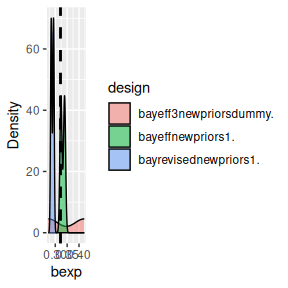

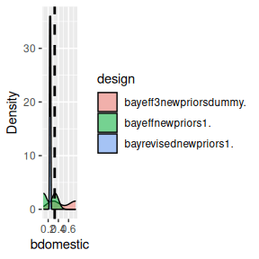

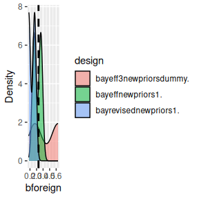

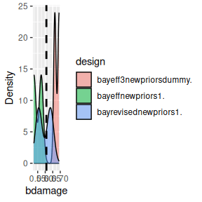

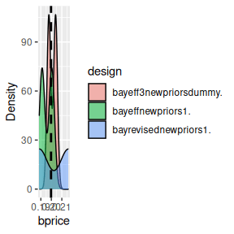

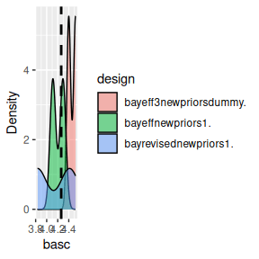

# Accessing the Output in R

The beta cofficients for each simulation are contained in a dataframe called coeffs located within {result}->{design}->coefs. and a summary table, which displays statistics of these b coefficients across all simulations is contained in {results}->{design}->summary. You can access these by either searching for a known design name or by browsing design names contained in the output list.

You can also save the results to disk using saveRDS(csa,file = “tests/manual-tests/csa.RDS”)

```r
designs <- names(seagri[sapply(seagri, is.list)])

print(designs)
```

```
#> [1] "bayeff3newpriorsdummy" "bayeffnewpriors1"      "bayrevisednewpriors1"
#> [4] "time"                  "arguements"            "summaryall"
#> [7] "graphs"                "powa"
```

```r
simulationCoeff <- seagri[[1]]$coefs
coeffSummary <- seagri[[1]]$summary

print(simulationCoeff)
```

```
#> # A tibble: 2 × 15
#>   run   est_bprof est_bexp est_bdomestic est_bforeign est_bdamage est_bprice
#>   <chr>     <dbl>    <dbl>         <dbl>        <dbl>       <dbl>      <dbl>
#> 1 1         0.541    0.422         0.297        0.274       0.693      0.204
#> 2 2         0.200    0.271         0.743        0.629       0.664      0.198
#> # ℹ 8 more variables: est_basc <dbl>, rob_pval0_bprof <dbl>,
#> #   rob_pval0_bexp <dbl>, rob_pval0_bdomestic <dbl>, rob_pval0_bforeign <dbl>,
#> #   rob_pval0_bdamage <dbl>, rob_pval0_bprice <dbl>, rob_pval0_basc <dbl>
```

```r
print(coeffSummary)
```

```
#>                     vars n mean   sd median  min  max range skew kurtosis   se
#> est_bprof              1 2 0.37 0.24   0.37 0.20 0.54  0.34    0    -2.75 0.17
#> est_bexp               2 2 0.35 0.11   0.35 0.27 0.42  0.15    0    -2.75 0.08
#> est_bdomestic          3 2 0.52 0.32   0.52 0.30 0.74  0.45    0    -2.75 0.22
#> est_bforeign           4 2 0.45 0.25   0.45 0.27 0.63  0.35    0    -2.75 0.18
#> est_bdamage            5 2 0.68 0.02   0.68 0.66 0.69  0.03    0    -2.75 0.01
#> est_bprice             6 2 0.20 0.00   0.20 0.20 0.20  0.01    0    -2.75 0.00
#> est_basc               7 2 4.46 0.09   4.46 4.40 4.52  0.12    0    -2.75 0.06
#> rob_pval0_bprof        8 2 0.03 0.05   0.03 0.00 0.07  0.07    0    -2.75 0.03
#> rob_pval0_bexp         9 2 0.01 0.01   0.01 0.00 0.02  0.02    0    -2.75 0.01
#> rob_pval0_bdomestic   10 2 0.00 0.01   0.00 0.00 0.01  0.01    0    -2.75 0.00
#> rob_pval0_bforeign    11 2 0.01 0.01   0.01 0.00 0.02  0.02    0    -2.75 0.01
#> rob_pval0_bdamage     12 2 0.00 0.00   0.00 0.00 0.00  0.00    0    -2.75 0.00
#> rob_pval0_bprice      13 2 0.00 0.00   0.00 0.00 0.00  0.00  NaN      NaN 0.00
#> rob_pval0_basc        14 2 0.00 0.00   0.00 0.00 0.00  0.00  NaN      NaN 0.00
```

```r
## saveRDS(csa,file = "tests/manual-tests/csa.RDS")
```